# Análise sobre dados de acesso de projetos da wikimedia

Veruska Santos

25 de abril de 2018

Este relatório é a resposta do exercício proposto pelo Wikimedia, disponível no GitHub¹.

## 1. Objetivo

Neste relatório, analisaremos os dados busca e navegação de projetos do Wikimedia e tentaremos responder as seguintes perguntas, separadamente:

1. Qual é a taxa de cliques geral diária? Como isso varia entre os grupos?
2. Quais resultados as pessoas tendem a tentar primeiro? Como isso muda no dia-a-dia?
3. Qual é a taxa de resultados zero no geral? Como isso varia entre os grupos?
4. A duração da sessão é aproximadamente o tempo entre o primeiro e o último evento de uma sessão. Escolha uma variável do conjunto de dados e descreva sua relação com o tamanho da sessão. Visualize o relacionamento.

Utilizaremos de visualizações e discussões dos resultados para responder às perguntas.

## 2. Configurações

Abaixo estão as dependências necessárias para reproduzir este relatório.

```r
library(tidyverse)
library(here)
library(lubridate)
```

O objeto principal da análise são as buscas e a navegação depois da busca. Criamos esses dados a partir dos dados originais da wikimedia em `/data/search_data.csv`.

```r
buscas = read_csv(here::here("data/search_data.csv"))
```

Adicionaremos uma nova variável **date** aos dados, que é a variável session_start_date sem a hora, para facilitar as análises e evitar repetição de código.

```r
buscas <- mutate(buscas, date = date(session_start_date))
```

## 3. Distribuição dos dados utilizados

Vejamos a definição das variáveis coletadas, que iremos utilizar na análise, e como estão distribuídos os dados na amostra disponibilizada.

Nas visualizaçãoes com histograma, mostraremos traços verdes abaixo das barras, em geral, que indicam a presença de valores naquela combinação (x,y), porque, em alguns casos, as barras não aparecem no gráfico, devido à escala.

- **num_clicks:** representa a quantidade total de vezes que o usuário clicou nos resultados de cada busca. Os valores variam entre 0 e 36 e a distribuição é decrescente, ou seja, há muitas buscas em que os usuários clicaram em poucos ou nenhum resultado.

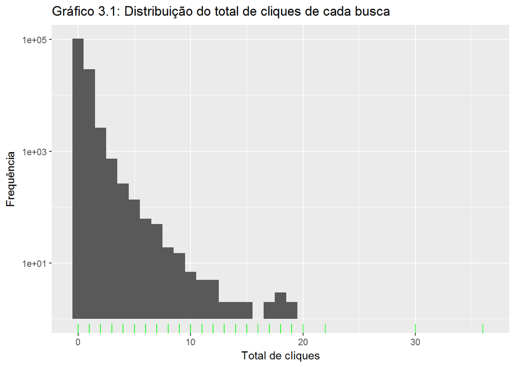

```r
buscas %>%
    ggplot(aes(x = num_clicks)) +
    geom_histogram(binwidth = 1) +
    scale_y_log10() +
    geom_rug(alpha = .7, color = "green") +
    labs(x = "Total de cliques", y = "Frequência",
    title = "Gráfico 3.1: Distribuição do total de cliques de cada busca")
```

- **group:** representa o grupo em que cada sessão está, logo, todas as buscas de uma sessão pertencem ao mesmo grupo. Os valores podem ser a ou b, porém a amostra está desbalanceada em relação aos grupos, pois possui mais buscas pertencentes ao grupo a do que ao grupo b.

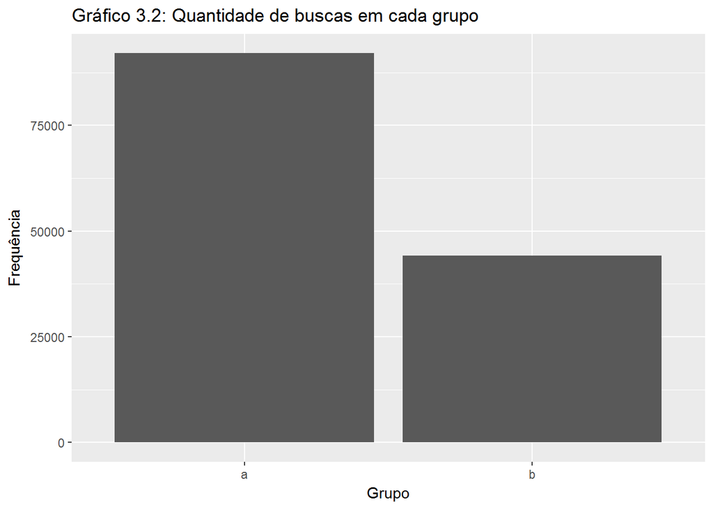

```r
buscas %>%
    ggplot(aes(x = group)) +
    geom_histogram(binwidth = 1, stat = "count") +
    labs(x = "Grupo", y = "Frequência", fill = "Grupo",
    title = "Gráfico 3.2: Quantidade de buscas em cada grupo")
```

- **date:** representa o dia em que cada busca foi realizada. Os dados foram coletados entre os dias 1 e 8 de março de 2016, durante todo o dia, exceto o dia 8, que tem dados de busca registrados até às 20h24, então, este dia pode ter poucas buscas por conta do período de coleta.

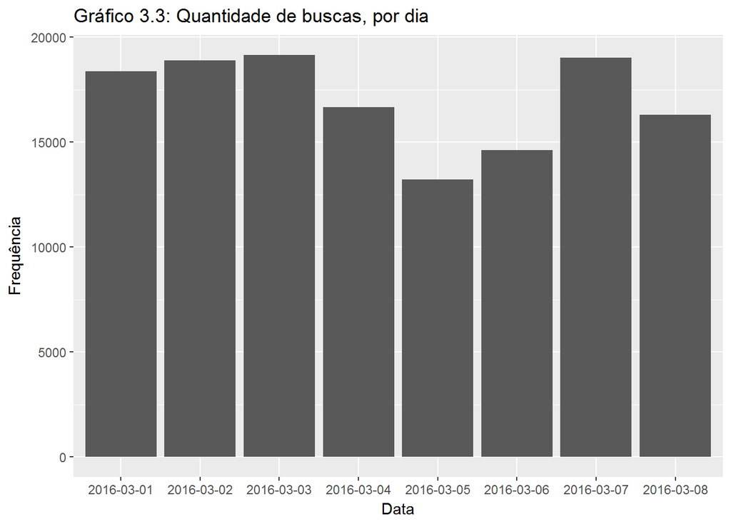

```r
buscas %>%
    ggplot(aes(x = factor(date))) +
    geom_histogram(binwidth = 0.5, stat="count") +
    labs(x = "Data", y = "Frequência",
    title = "Gráfico 3.3: Quantidade de buscas, por dia")
```

- **results:** É a quantidade total de resultados que cada busca retornou. Os valores estão entre 0 e 500, porém a maioria das buscas retornou entre 0 e 20 resultados.

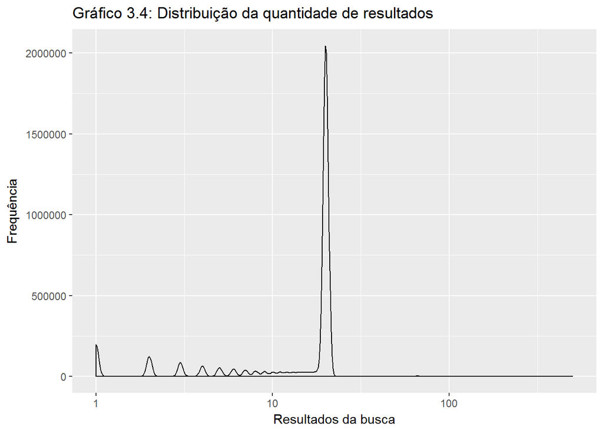

```r
buscas %>%
    ggplot(aes(x = results, y = ..count..)) +
    geom_density() +
    scale_x_log10() +
    labs(x = "Resultados da busca", y = "Frequência",
    title = "Gráfico 3.4: Distribuição da quantidade de resultados")
```

- **first_click:** representa qual foi o resultado que o usuário clicou primeiro, de cada busca, ou seja, a posição do primeiro resultado clicado. Os valores podem ser entre 1 e 4103 ou NA (sem valor), porém estão concentrados entre 0 e 20, sendo a relação decrescente, ou seja, os usuários tendem a clicar nos primeiros resultados.

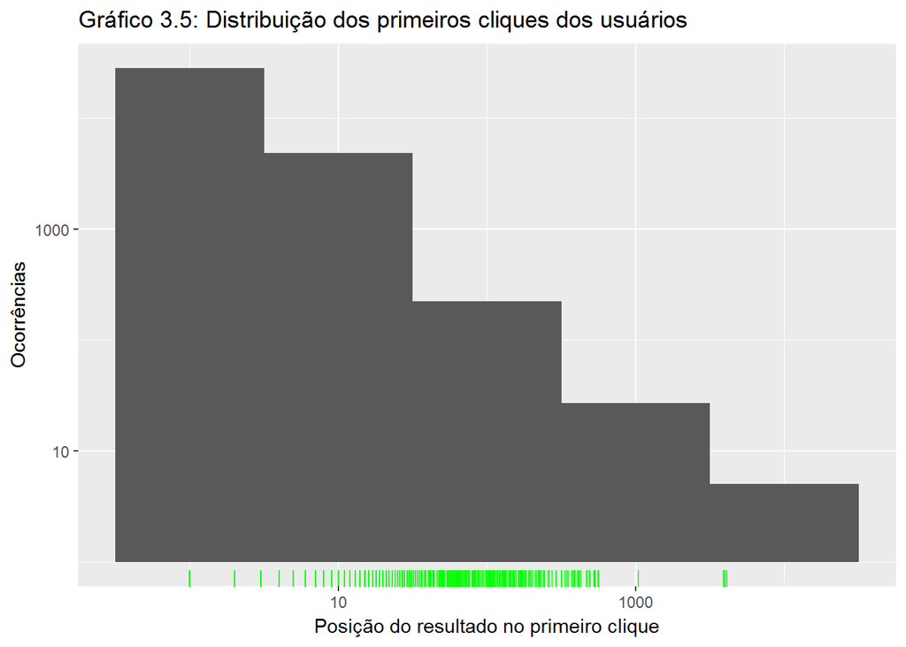

```r
buscas %>%
    ggplot(aes(x = first_click)) +
    geom_histogram(binwidth = 1) +
    geom_rug(alpha = .7, color = "green") +
    scale_x_log10() +
    scale_y_log10() +
    labs(x = "Posição do resultado no primeiro clique", y = "Ocorrências",
    title = "Gráfico 3.5: Distribuição dos primeiros cliques dos usuários")
```

- **session_start_timestamp:** representa o tempo, em milissegundos, do começo da sessão, ou seja, é o tempo registrado no começo da primeira busca. Para analisar sua distribuição, particionamos a hora em turnos e mostramos no gráfico abaixo, onde percebemos que as sessões começam mais no turno da tarde e menos de madrugada.

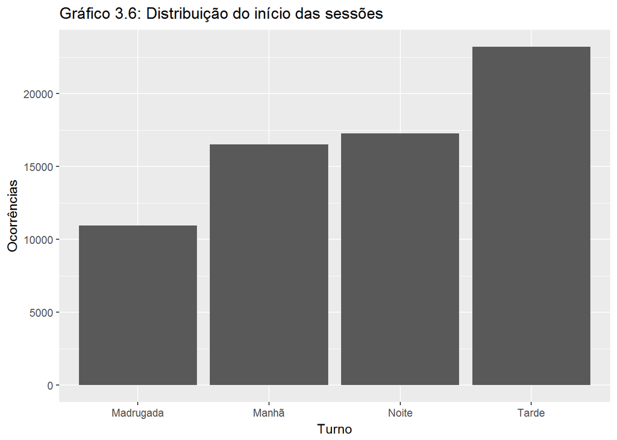

```r
sessoes_agrupadas <- buscas %>%
    group_by(session_id) %>%
    summarise(first_time = first(session_start_date))

datas_por_turno <- ifelse(as.numeric(substr(sessoes_agrupadas$first_time, 12, 13)) < 6,"Madrugada",
                    ifelse(as.numeric(substr(sessoes_agrupadas$first_time, 12, 13)) < 12,"Manhã",
                         ifelse(as.numeric(substr(sessoes_agrupadas$first_time, 12, 13)) < 18,"Tarde",
                                ifelse(as.numeric(substr(sessoes_agrupadas$first_time, 12, 13)) <= 23,"Noite"))))

sessoes_agrupadas %>%
    ggplot(aes(x = datas_por_turno)) +
    geom_histogram(binwidth = 0.5, stat = "count") +
    labs(x = "Turno", y = "Ocorrências",
    title = "Gráfico 3.6: Distribuição do início das sessões")
```

- **session_last_timestamp:** representa o tempo, em milissegundos, do final da sessão, ou seja, é o tempo registrado no final da última busca. Assim como na variável anterior, particionamos a hora em turnos e mostramos no gráfico abaixo, onde percebemos que as sessões terminam mais no turno da tarde e menos de madrugada.

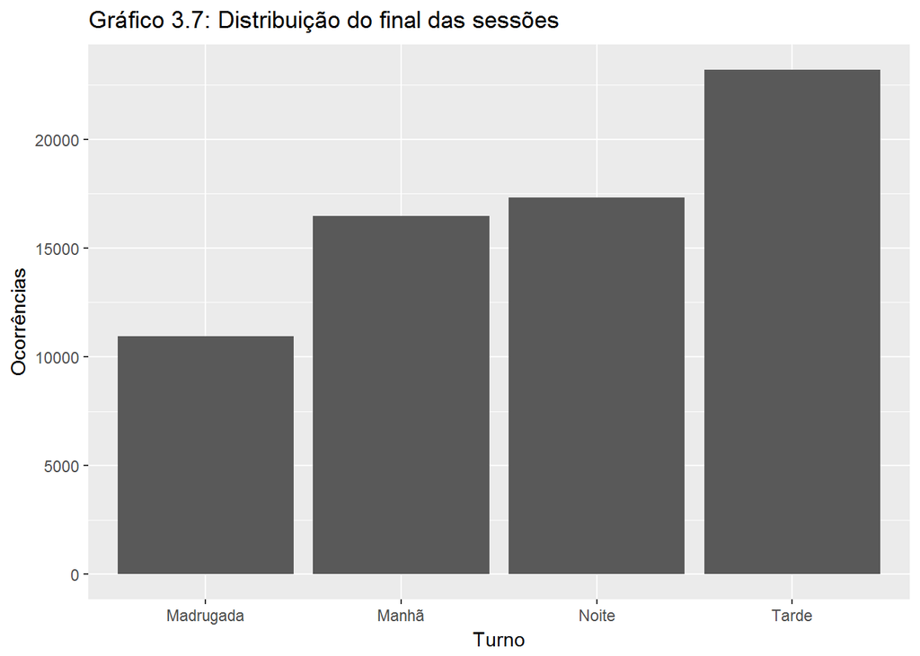

```r
sessoes_agrupadas <- buscas %>%
    group_by(session_id) %>%
    summarise(last_time = last(session_last_date))

datas_por_turno <- ifelse(as.numeric(substr(sessoes_agrupadas$last_time, 12, 13)) < 6,"Madrugada",
                    ifelse(as.numeric(substr(sessoes_agrupadas$last_time, 12, 13)) < 12,"Manhã",
                         ifelse(as.numeric(substr(sessoes_agrupadas$last_time, 12, 13)) < 18,"Tarde",
                                ifelse(as.numeric(substr(sessoes_agrupadas$last_time, 12, 13)) <= 23,"Noite"))))

sessoes_agrupadas %>%
    ggplot(aes(x = datas_por_turno)) +
    geom_histogram(binwidth = 0.5, stat = "count") +
    labs(x = "Turno", y = "Ocorrências",
    title = "Gráfico 3.7: Distribuição do final das sessões")
```

## 4. Análise dos dados

Agora, utilizaremos de visualizações e discussões dos resultados para analisar os dados e responder as perguntas já descritas.

### 4.1 Qual é a taxa de cliques geral diária? Como isso varia entre os grupos?

Para responder esta pergunta, iremos usar as variáveis **num_clicks**, **date** e **group** e calcularemos a taxa, que é a soma dos cliques do dia dividido pelo total de buscas do referido dia, ou seja,

**taxa de cliques** = soma dos cliques do dia / total de buscas do dia.

Removeremos o dia 8 de março da análise, porque, como discutido na sessão 3 anterior, a coleta das buscas não considerou o dia inteiro, logo, a comparação com os outros dias seria enviesada.

```r
buscas_sem_dia_8 <- buscas %>%
    filter(date != "2016-03-08")
```

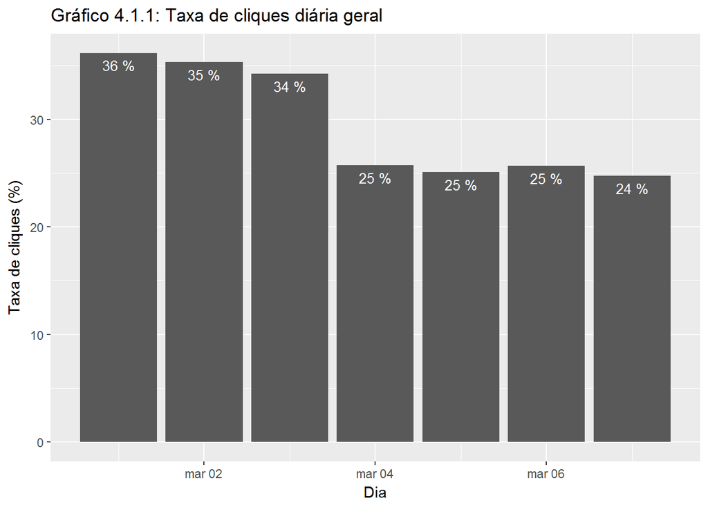

```r
total_buscas_dia <- buscas_sem_dia_8 %>%
    group_by(date) %>%
    count(date)

total_cliques <- buscas_sem_dia_8 %>%
    group_by(date) %>%
    summarise(clicks = sum(num_clicks))

merge_cliques_buscas <- merge(total_cliques, total_buscas_dia)

taxa_cliques_total <- merge_cliques_buscas%>%
    ggplot(aes(x = date, y = (clicks/n)*100)) +
    geom_col(position = "dodge") +
    geom_text(aes(x = date, y = (clicks/n)*100, label=paste(trunc((clicks/n)*100), "%")), vjust=1.6, color="white", size=3.5) +
    labs(x = "Dia", y = "Taxa de cliques (%)",
         title = "Gráfico 4.1.1: Taxa de cliques diária geral")

print(taxa_cliques_total)
```

Mais abaixo, no Gráfico 4.1.2, mostramos a variação da taxa de cliques por grupo, onde há discrepância. Observe.

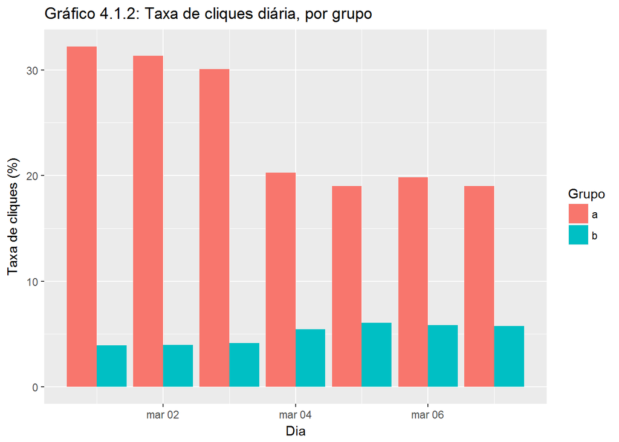

```r
total_cliques <- buscas_sem_dia_8 %>%
    group_by(date, group) %>%
    summarise(clicks = sum(num_clicks))

merge_cliques_buscas <- merge(total_cliques, total_buscas_dia)

taxa_cliques_grupos <- merge_cliques_buscas %>%
    ggplot(aes(x = date, y = (clicks/n)*100, fill = group)) +
    geom_col(position = "dodge") +
    labs(x = "Dia", y = "Taxa de cliques (%)", fill = "Grupo",
         title = "Gráfico 4.1.2: Taxa de cliques diária, por grupo")

print(taxa_cliques_grupos)
```

O grupo a apresenta as maiores taxas de cliques em todos os dias analisados e uma tendência decrescente no decorrer dos dias. Já o grupo b, apresenta uma certa relação crescente, apesar dos valores ainda serem mais baixos do que os do grupo a, por conta do desbalanceamento da quantidade de buscas de cada grupo, também discutido na sessão 3 anterior.

### 4.2 Quais resultados as pessoas tendem a tentar primeiro? Como isso muda no dia-a-dia?

Para responder esta pergunta, iremos usar as variáveis **results**, **first_click** e **date**.

Como para buscas sem resultados, em geral, não há nenhum clique (há 4 exceções nos dados), removeremos as buscas cujo resultado foi zero e não possui valores registrados para o primeiro clique. Assim, filtraremos e analisaremos apenas as buscas que têm 1 ou mais resultados e valores de primeiro clique registrados.

```r
buscas_com_resultado <- buscas %>%
    filter(results > 0, !is.na(first_click))
```

O filtro acima resultou em 33.187 dados que iremos analisar, sendo, 122 destes, buscas cujo índice do primeiro clique é maior que 100. Essas 122 buscas removeremos do gráfico abaixo, para facilitar a visualização da maioria dos dados, mas em seguida, no Gráfico 4.2.2, os mostraremos novamente através do boxplot.

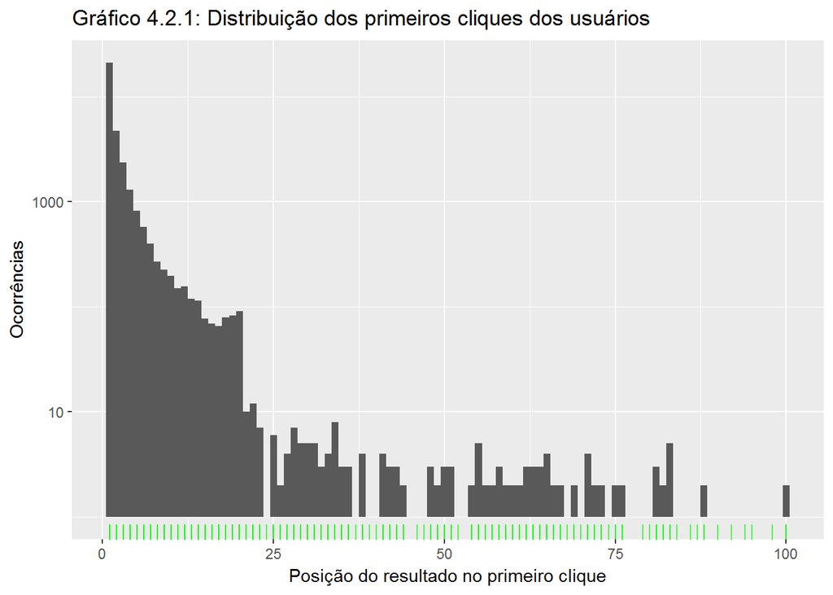

```r
buscas_com_resultado %>%
    filter(first_click <= 100) %>%
    ggplot(aes(x = first_click)) +
    geom_histogram(binwidth = 1) +
    geom_rug(alpha = .7, color = "green") +
    scale_y_log10() +
    labs(x = "Posição do resultado no primeiro clique", y = "Ocorrências",
         title = "Gráfico 4.2.1: Distribuição dos primeiros cliques dos usuários")
```

O eixo x do gráfico acima exibe qual foi o primeiro clique do usuário, ou seja, em qual posição o resultado da busca estava. Assim, os usuários tendem, claramente, a clicar no primeiro resultado da busca, depois no segundo e assim, sucessivamente, devido à tendência decrescente exibida no gráfico, o que indica que os algoritmos de rankeamento da plataforma estão adequados. Apesar disso, há poucas ocorrências, menos de 10 por posição, em que o primeiro clique do usuário foi em um resultado posicionado após 25 ou mais respostas. Há ainda uma elevação nos valores, após a metade do intervalo [0, 25] que, seguindo o padrão de configuração das páginas, significa possivelmente os primeiros resultados da segunda página.

Agora, verificaremos a preferência dos resultados por dia. O gráfico abaixo exibe os boxplots, representados pela cor verde, para cada dia. Os pontos são as buscas e o eixo y representa qual a posição do primeiro resultado que o usuário clicou.

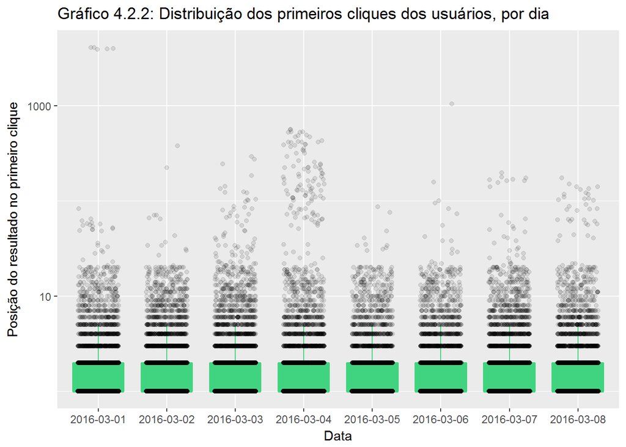

```r
buscas_com_resultado %>%
    ggplot(aes(x = factor(date), y = first_click)) +
    geom_boxplot(outlier.shape=NA, color = "#41d480", fill = "#41d480") +
    geom_jitter(alpha = .1, width = .3) +
    scale_y_log10() +
    labs(x = "Data", y = "Posição do resultado no primeiro clique",
         title = "Gráfico 4.2.2: Distribuição dos primeiros cliques dos usuários, por dia")
```

Em geral, não há diferença significativa entre os primeiros cliques dos usuários entre os dias, porque os boxplots (retângulos verdes) parecem apresentar as mesmas características. Exceto no dia 04, onde houve mais cliques nos resultados de índices altos, ou seja, há mais pontos, que representam as buscas, na parte superior do gráfico. Em todos os dias, os resultados que os usuários clicam primeiro estão, em sua maioria, entre 1 e 3, aproximadamente, sendo o primeiro resultado da busca o valor mediano, confirmando os resultados obtidos no Gráfico 4.2.1. No primeiro e no sexto dia desses dados há buscas em que os usuários clicaram nos resultados acima da posição 1000, o que dá indicíos de que os usuários eram robôs.

### 4.3 Qual é a taxa de resultados zero no geral? Como isso varia entre os grupos?

Para responder esta pergunta, iremos usar as variáveis **results** e **group**. Diferente da pergunta anterior, onde removemos as buscas cujo resultado era zero, agora iremos analisar a sua frequência em relação ao total de buscas.

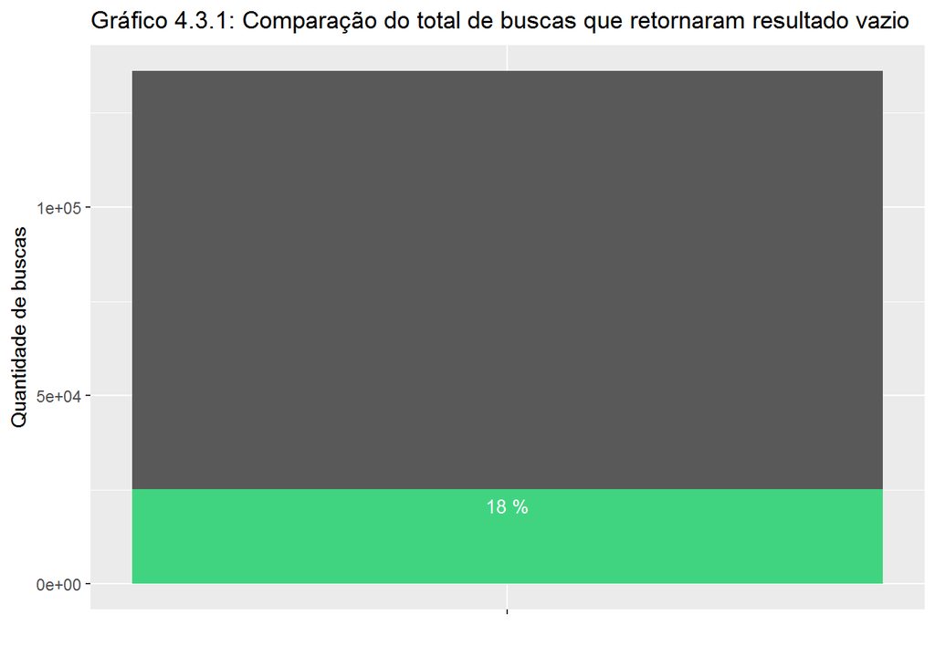

```r
buscas_sem_resultado <- buscas %>%
    filter(results == 0)

total_com_resultado <- buscas %>%
    summarise(n_total = n())

total_sem_resultado <- buscas_sem_resultado %>%
    summarise(n_vazio = n())

merge(total_com_resultado, total_sem_resultado) %>%
    ggplot() +
    geom_col(aes(x = "", y = n_total)) +
    geom_col(aes(x = "", y = n_vazio), fill = "#41d480") +
    geom_text(aes(x = "", y = n_vazio, label=paste(trunc((n_vazio/n_total)*100), "%")), vjust=1.6, color="white", size=3.5) +
    labs(x = "", y = "Quantidade de buscas",
         title = "Gráfico 4.3.1: Comparação do total de buscas que retornaram resultado vazio")
```

O gráfico acima mostra que há 25.127 buscas, de um total de 136234, que retornaram nenhum resultado, ou seja, **18%** de todas as buscas retornaram resultado vazio. Desses resultados vazios, 16902 foram do grupo a, que possuem 92056 buscas, enquanto 8225 foram do grupo b, que possuem 44178, como podemos ver logo abaixo, no Gráfico 4.3.2. Portanto, **18%** das buscas do grupo a e também **18%** do grupo b retornaram resultado vazio.

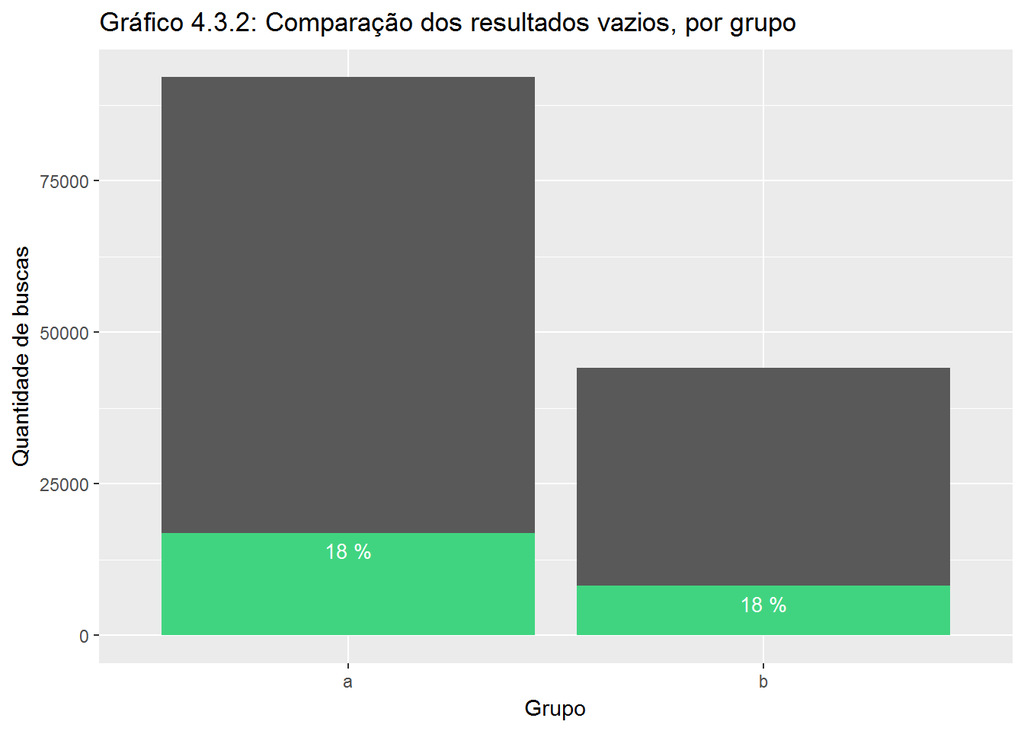

```r
total_com_resultado <- buscas %>%
    group_by(group) %>%
    summarise(n_total = n())

total_sem_resultado <- buscas_sem_resultado %>%
    group_by(group) %>%
    summarise(n_vazio = n())

merge(total_com_resultado, total_sem_resultado) %>%
    ggplot() +
    geom_col(aes(x = group, y = n_total)) +
    geom_col(aes(x = group, y = n_vazio), fill = "#41d480") +
    geom_text(aes(x = group, y = n_vazio, label=paste(trunc((n_vazio/n_total)*100), "%")), vjust=1.6, color="white", size=3.5) +
    labs(x = "Grupo", y = "Quantidade de buscas",
         title = "Gráfico 4.3.2: Comparação dos resultados vazios, por grupo")
```

Apesar do grupo b ter menos dados, a taxa de resultados vazio foi igual ao grupo a. Será que, se os dados tivessem igualmente distribuidos, as buscas do grupo b teriam bem mais resultados vazios do que o grupo a?

Não sabemos responder!

Vamos para a quarta e última pergunta.

### 4.4 A duração da sessão é aproximadamente o tempo entre o primeiro e o último evento de uma sessão. Escolha uma variável do conjunto de dados e descreva sua relação com o tamanho da sessão. Visualize o relacionamento.

Iremos analisar a relação entre a duração da sessão e o grupo que ela pertence. Assim, utilizaremos as variáveis **session_start_timestamp**, **session_last_timestamp** e **group**. A partir das duas primeiras variáveis calcularemos a duração da sessão, que é a diferença do último tempo registrado da última busca e o tempo inicial da primeira busca da sessão, ou seja,

**duração:** tempo final da sessão - tempo inicial da sessão.

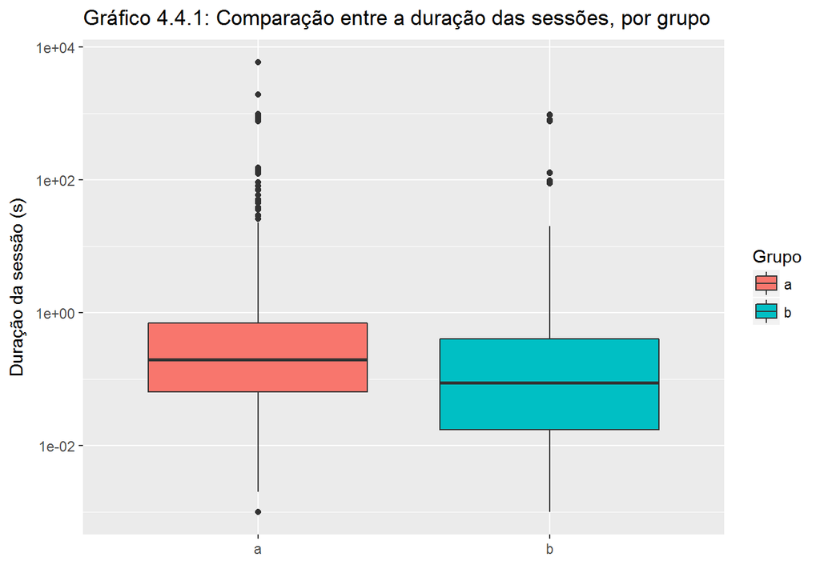

```r
buscas %>%
    group_by(session_id) %>%
    summarise(total_cliques = sum(num_clicks), group = first(group), duration = last(session_last_timestamp) - first(session_start_timestamp)) %>%
    ggplot(aes(x = group, y = duration/1000, fill = group)) +
    geom_boxplot() +
    scale_y_log10() +
    labs(x = "", y = "Duração da sessão (s)", fill = "Grupo",
         title = "Gráfico 4.4.1: Comparação entre a duração das sessões, por grupo")
```

O gráfico acima nos mostra que as sessões do grupo a duram mais tempo, em geral, que as sessões do grupo b, pois o boxplot do grupo a, que representa a distribuição dos dados, está mais acima do que o boxplot do grupo b.

## 5. Conclusões

Nesta análise, procuramos responder às perguntas do exercício disponibilizados pelo Wikimedia, onde utilizamos, principalmente, de histogramas para verificar a distribuição dos dados. Para verificar relações utilizamos boxplots, que mostra também a distribuição de dados, porém de forma sumarizada e, por fim, gráficos de coluna, pareados ou sobrepostos, para facilitar a comparação entre 2 ou mais variáveis.

## 6. Referências

¹ https://github.com/wikimedia-research/Discovery-Hiring-Analyst-2016